# Optimizing Patient Routing

Disaster Scenarios for MCI Frameworks

Brianna Monti · Xuzhe Zhi · Yusi Yao · Andzani Mthenjane

November 12, 2026

## The response problem

Which ambulance takes which casualty to which hospital?

- **Setting:** a blast event at Oriole Park at Camden Yards in Baltimore.
- **Resources:** a limited ambulance fleet and hospitals with different trauma capabilities and free capacity.
- **Purpose:** a virtual Emergency Medical Resource Center (EMRC) for planning and training.

## An incident that changes over time

### START triage

| Tag | Category |
| --- | --- |
| **RED** | Immediate |
| **YELLOW** | Delayed |
| **GREEN** | Minor |
| **BLACK** | Expectant |

### Changing conditions

- New casualties appear and complete triage.
- Waiting patients may deteriorate.
- Ambulances return for repeated trips.
- Hospital capacity fills and roads may be restricted.

## Data and assumptions

| Input | Source or treatment |
| --- | --- |
| Road network and driving times | OpenStreetMap, routed with Valhalla |
| Casualty numbers | Random generation anchored to Maryland MCI evidence |
| Hospital locations and attributes | HIFLD Open Hospitals layer |
| Operational setting | MIEMSS EMRC and Maryland EMS regulations |

Casualty demand and available resources remain scenario inputs. Experiments will test how results change when those inputs vary.

## Routing, assignment and simulation

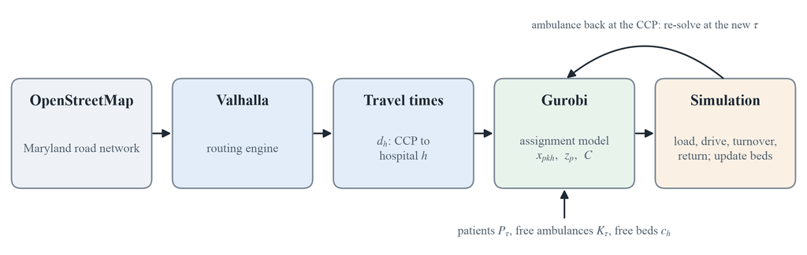

**Valhalla** supplies travel times. **Gurobi** chooses assignments. The **simulation** executes trips and updates the next decision state.

## Travel times from Valhalla

### Road network routing

The simulation requests a driving route between two coordinates.

Valhalla returns travel time in seconds. The simulator converts it to minutes for the assignment model.

```python
response = requests.post(
    f"{VALHALLA_URL}/route",
    json=payload,
    timeout=60
)

response.raise_for_status()

result = response.json()
summary = result["trip"]["summary"]
```

Source: `dynamic_mci/simulation/engine.py` · `get_route()`

## The assignment model at time $\tau$

### Eligible sets

| Set | Meaning |
| --- | --- |
| $P_\tau$ | Triaged patients waiting for transport |
| $K_\tau$ | Ambulances free at the CCP |
| $H_\tau$ | Hospitals with free beds |

| Symbol | Meaning |
| --- | --- |
| $\ell$ | Loading time |
| $d_h$ | Travel time to hospital $h$ |
| $c_h$ | Available beds at hospital $h$ |
| $g_{ph}$ | Patient–hospital compatibility |

Patient $p$ enters the eligible set after triage is complete: $r_p\le\tau$.

## Decision variables in Gurobi

| Variable | Meaning |
| --- | --- |
| $x_{pkh}$ | Patient–ambulance–hospital assignment |
| $z_p$ | Patient receives an assignment |
| $C$ | Latest arrival in the batch |

The code uses `a` for the ambulance index and `makespan` for $C$.

```python
x = model.addVars(
    P, A, H,
    vtype=GRB.BINARY,
    name="assignment"
)
z = model.addVars(
    P,
    vtype=GRB.BINARY,
    name="assigned"
)
makespan = model.addVar(
    lb=0,
    vtype=GRB.CONTINUOUS,
    name="makespan"
)
```

Source: `dynamic_mci/optimization/optimizer/mci_ambulance_gurobi.py` · `optimize_mci()`

## Objective priorities

The assignment model uses a lexicographic objective.

| Order | Objective |
| --- | --- |
| 1 | Maximize RED assignments: $\max\sum_{p\in P_\tau^{\mathrm{RED}}}z_p$ |
| 2 | Maximize YELLOW assignments: $\max\sum_{p\in P_\tau^{\mathrm{YELLOW}}}z_p$ |
| 3 | Maximize GREEN assignments: $\max\sum_{p\in P_\tau^{\mathrm{GREEN}}}z_p$ |
| 4 | Minimize the latest arrival: $\min C$ |

Each lower objective preserves the best value of the higher objectives.

## Objective priorities in Gurobi

### `setObjectiveN()`

The preceding loop sets:

- RED: priority **4**
- YELLOW: priority **3**
- GREEN: priority **2**

`weight=-1` maximizes assignments under the model’s default minimization sense. Makespan has priority **1**.

```python
model.setObjectiveN(
        gp.quicksum(z[p] for p in group),
        index=4-priority,
        priority=priority,
        weight=-1,
        name=f"assign_{triage}"
    )

model.setObjectiveN(
    makespan,
    index=3,
    priority=1,
    weight=1,
    name="minimize_makespan"
)
```

Source: `dynamic_mci/optimization/optimizer/mci_ambulance_gurobi.py` · excerpt from `optimize_mci()`

## Feasible assignments

### Resource limits

- Each patient receives at most one assignment.
- Each free ambulance carries at most one patient in the batch.
- Assignments cannot exceed hospital bed capacity.

### Hospital and timing limits

- Each destination must be compatible with the patient’s triage tag.
- Unreachable hospitals are excluded.
- Arrival includes the current time, loading and travel.

$$C\geq(\tau+\ell+d_h)x_{pkh}$$

## Assignment constraints in code

### Patient assignment

$$\sum_{k,h}x_{pkh}=z_p$$

A binary $z_p$ permits at most one assignment.

### Ambulance capacity

$$\sum_{p,h}x_{pkh}\leq1$$

One patient per ambulance in each batch.

```python
for p in P:
    model.addConstr(
        gp.quicksum(
            x[p, a, h]
            for a in A for h in H
        ) == z[p]
    )

for a in A:
    model.addConstr(
        gp.quicksum(
            x[p, a, h]
            for p in P for h in H
        ) <= 1
    )
```

Source: `dynamic_mci/optimization/optimizer/mci_ambulance_gurobi.py` · `optimize_mci()`

## Reoptimization during the response

1. Observe waiting patients, free ambulances and available beds.
2. Solve the current assignment batch.
3. Execute loading, transport, hospital turnover and return.
4. Update the state and solve again when an ambulance is available.

The simulation connects repeated assignment decisions over the incident.

## Current dashboard implementation

| Report’s batch model | Dashboard’s dynamic mode |
| --- | --- |
| Assigns all currently free ambulances in a batch | Selects one patient and hospital when the ambulance is free |
| RED, YELLOW, GREEN counts, then makespan | Observed triage priority, waiting time, travel time, tie-breaking |
| Repeated batches connect through simulation | Rolling triage, reassessment, stabilization and bed reservations |

The current dynamic scheduler requires one ambulance. The following screenshots show a synthetic demonstration of that implementation.

## Dashboard: scenario inputs

[figure not shown]

`camden_yards_dynamic`: four synthetic patients, including one BLACK patient who does not require transport.

## Dashboard: simulation playback

[figure not shown]

One ambulance, three Gurobi dispatch decisions, and a last delivery at **196.5 minutes**.

## Dashboard: patient and hospital results

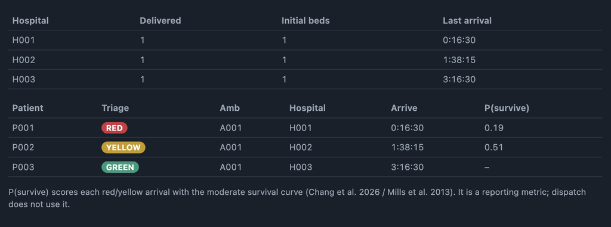

**3 delivered, 1 expectant.** Each receiving hospital uses its one available bed in this example. Survival scores are reporting metrics only.

## Planned evaluation

| Comparison | Question |
| --- | --- |
| Simple response policies | How much does optimization improve the response? |
| Documented MCI scenarios | How do different casualty counts and triage mixes affect performance? |
| Dynamic scenarios | What changes as patients deteriorate and vehicles become available? |
| Resource and road stress tests | Where do extra ambulances or beds help most? |

Baltimore remains the primary setting. Transfer to another city is an extension if time permits.

## Expected outputs

### Response performance

Patient throughput and waiting time, incident clearance time, resource utilization and unserved patients.

### Solver performance

Runtime and optimality gap.

The planning question: what can the available resources achieve, and where would added capacity help?

## Project timeline

| Milestone | Planned status |
| --- | --- |
| End of week 1 | Align formulation and code, consolidate features on main |
| End of week 2 | Freeze baseline resources and test patient scenarios |
| End of week 3 | Complete experiments and draft Results |
| Week 4 | Writing and validation, with no new modelling |

## Appendix: assignment and capacity

**C1. Patient assignment**

$$\sum_{k\in K_\tau}\sum_{h\in H_\tau}x_{pkh}=z_p\qquad\forall p\in P_\tau$$

**C2. Ambulance capacity**

$$\sum_{p\in P_\tau}\sum_{h\in H_\tau}x_{pkh}\leq1\qquad\forall k\in K_\tau$$

**C3. Hospital capacity**

$$\sum_{p\in P_\tau}\sum_{k\in K_\tau}x_{pkh}\leq c_h\qquad\forall h\in H_\tau$$

## Appendix: compatibility and arrival

**C4. Hospital compatibility**

$$x_{pkh}\leq g_{ph}\qquad\forall p\in P_\tau,k\in K_\tau,h\in H_\tau$$

**C5. Latest arrival in the batch**

$$C\geq(\tau+\ell+d_h)x_{pkh}\qquad\forall p\in P_\tau,k\in K_\tau,h\in H_\tau$$

**Variable domains**

$$x_{pkh},z_p\in\{0,1\},\qquad C\geq0$$

Set $x_{pkh}=0$ when hospital $h$ has no route from the CCP.

## Appendix: sources

- Repoussis, P. P., Paraskevopoulos, D. C., Vazacopoulos, A. & Hupert, N. (2016). Optimizing emergency preparedness and resource utilization in mass-casualty incidents. *European Journal of Operational Research*, 255, 531–544. [doi:10.1016/j.ejor.2016.05.047](https://doi.org/10.1016/j.ejor.2016.05.047)
- Branas, Sing & Perron. [Maryland MCI case series](https://pubmed.ncbi.nlm.nih.gov/11045407/)
- [OpenStreetMap](https://www.openstreetmap.org/) and Valhalla
- [HIFLD Open Hospitals archive](https://portal.datarescueproject.org/datasets/hifld-open-hospitals/)
- [MIEMSS Emergency Medical Resource Center](https://www.miemss.org/home/departments/emrc) and [COMAR 10.16.05.06](https://regs.maryland.gov/us/md/exec/comar/10.16.05.06)